# Statistical inference

Daniel Hammarström

22 10 2021

## Population and sample

- In statistics, a population is a defined collection of **all possible observations**.
- The population is never (or rarely) investigated in full, instead we draw a **sample** from the population to represent it.
- To make sure a sample is representative, techniques such as *random sampling* or *stratified random sampling*
- In real life, we might have investigations without random sampling, but we pretend as is if we did…

## Sampling and estimation

- In frequentist statistics, the population characteristics are **fixed but unknown**, we use the sample to estimate them.
- For a specific question, we usually draw only a limited number of samples (limited number of studies).
- A sample can be used to estimate the mean together with some uncertainty. The uncertainty is estimated from a imaginary **sampling distribution**.
- A sampling distribution is a distribution of e.g. sample averages drawn from the population with a certain sample size.

## A sampling distribution

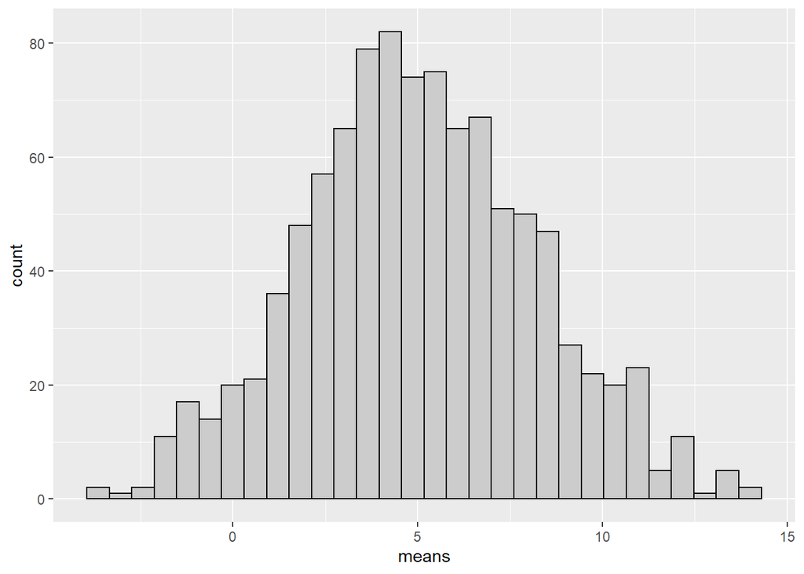

```r
set.seed(10)
library(tidyverse)

population <- rnorm(10^6, mean = 5, sd = 10)


results <- data.frame(means = rep(NA, 1000))


for(i in 1:1000) {

  samp <- sample(population, 10, replace = FALSE)

  results[i, 1] <- mean(samp)


}


results %>%
  ggplot(aes(means)) + geom_histogram(color = "black", fill = "gray80")
```

- This is a simulated example of a sampling distribution, 1000 studies, each with $n=10$ drawn from a fixed population.
- The center of the distribution (mean of means) is pretty close to the population mean (5). The spread of the distribution represents different possible means and can be used to represent our uncertainty.
- Using a single sample we can make a pretty informed guess about the distribution of imaginary samples.
- **The standard error of the mean is an estimate of the standard deviation in the sampling distribution**.
- The standard error of the mean depends on the estimated standard deviation and the sample size. If the sample size increases we get *“more certain”*.

$$SE = \frac{s}{\sqrt{n}}$$

```r
set.seed(10)


population <- rnorm(10^6, mean = 5, sd = 10)


results <- data.frame(means = rep(NA, 1000),
                      sd = rep(NA, 1000))


for(i in 1:1000) {

  samp <- sample(population, 10, replace = FALSE)

  results[i, 1] <- mean(samp)
  results[i, 2] <- sd(samp)

}

results <- results %>%
  mutate(se = sd / sqrt(10))


head(results)
```

```
##      means        sd       se
## 1 3.557810  8.865749 2.803596
## 2 5.202768  6.519871 2.061764
## 3 4.375970  8.518785 2.693876
## 4 1.266714 10.113868 3.198286
## 5 3.502865  9.602975 3.036727
## 6 5.394070  8.127439 2.570122
```

```r
sd(results$means)
```

```
## [1] 3.147011
```

```r
mean(results$se)
```

```
## [1] 3.029335
```

## The effect of sample size on the sample distribution

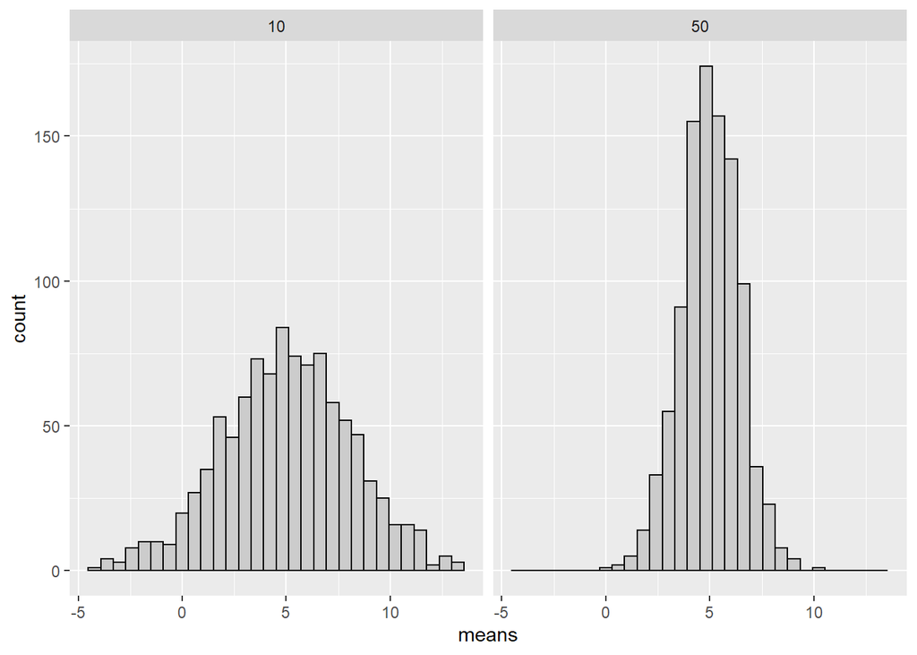

```r
set.seed(10)


population <- rnorm(10^6, mean = 5, sd = 10)


results <- data.frame(means = rep(NA, 1000),
                      sd = rep(NA, 1000))

results50 <- data.frame(means = rep(NA, 1000),
                      sd = rep(NA, 1000))




for(i in 1:1000) {

  samp <- sample(population, 10, replace = FALSE)

  results[i, 1] <- mean(samp)
  results[i, 2] <- sd(samp)


  samp50 <- sample(population, 50, replace = FALSE)

  results50[i, 1] <- mean(samp50)
  results50[i, 2] <- sd(samp50)


}


bind_rows(results %>% mutate(n = 10),
          results50 %>% mutate(n = 50)) %>%
  ggplot(aes(means)) + geom_histogram(color = "black", fill = "gray80") +
  facet_wrap(~ n)
```

- With a larger sample size there is a smaller spread in the distribution of samples.

```r
bind_rows(results %>% mutate(n = 10),
          results50 %>% mutate(n = 50)) %>%
  group_by(n) %>%
  summarise(se_average = mean(sd/sqrt(n)),
            se_observed = sd(means)) %>%
  print()
```

```
## # A tibble: 2 x 3
##       n se_average se_observed
##   <dbl>      <dbl>       <dbl>
## 1    10       3.08        3.11
## 2    50       1.41        1.41
```

## How likely are we to find an effect in a sample? Statistical power.

- In the population above, the average is 5 and the standard deviation is 10. How likely are we to find a result that can rule out “not different from zero”?
- We can make a hypothesis test of the effect in the population against the null hypothesis:

$$H_0: \mu = 0$$
- This is a *one-sample* test, it can be performed with a simple linear model

```r
# Example sample

samp <- sample(population, 15, replace = FALSE)

summary(lm(y ~ 1, data = data.frame(y = samp)))
```

```
##
## Call:
## lm(formula = y ~ 1, data = data.frame(y = samp))
##
## Residuals:
##      Min       1Q   Median       3Q      Max
## -18.4580  -4.3140   0.0059   5.5999  11.6139
##
## Coefficients:
##             Estimate Std. Error t value Pr(>|t|)
## (Intercept)    5.773      2.076   2.781   0.0147 *
## ---
## Signif. codes:  0 '***' 0.001 '**' 0.01 '*' 0.05 '.' 0.1 ' ' 1
##
## Residual standard error: 8.04 on 14 degrees of freedom
```

## Building a simulation experiment

We now will build a simulation study to investigate

- How often will we find a “true” population effect in studies of different sizes?
- What is the relationship between effect size, power and statistical significance?
- What is the effect of sample size on the precision of estimates (confidence intervals)

Our simulation will investigate a known population effect of 0.5. This standardized effect ($d$) is in the *one-sample* case $d = \frac{mean}{SD}$.

```r
library(tidyverse)
set.seed(1)


# Create a population to sample from with a known effect
# In standardized terms, the population effect is 0.5 = mean / sd.


population <- rnorm(10^6, 5, 10)

# Calculate the population effect size
pop.es <- mean(population) / sd(population)


results_total <- list()



# If use a progress bar
# pb <- txtProgressBar(min = 0, max = 1000, style = 3)


# 0. Inside for-loop:




for(i in 1:1000) {

# 1. Sample from the population with sample size 10 to 100

  # 1.1 create a vector of sample sizes
  sample.sizes <- seq(from = 10, to = 100, by = 10)
  # 1.2 create a list to store results
  results_sub <- list()

  # 1.3 Inside a nested for-loop, perform sampling with each sample size
  for(j in 1:length(sample.sizes)) {

  samp <- sample(population, sample.sizes[j],
                 replace = FALSE)


# 2. Create a model

  m <- lm(y ~ 1, data = data.frame(y = samp))

  # 2.1 Store results from each model as a data frame in a list:

 results_sub[[j]] <- data.frame(mean = coef(summary(m))[1, 1],  # Estimated mean
             se = coef(summary(m))[1, 2],  # Standard error
             pval = coef(summary(m))[1, 4],  # p-value
             ci.lwr = confint(m)[1], # confidence interval
             ci.upr = confint(m)[2], # confidence interval
             effect.size = mean(samp) / sd(samp),
             sample.size = sample.sizes[j]) # Sample size



  }
  # 2.2 Combine all data frames from each sample size as a data frame in a list

  results_total[[i]] <- bind_rows(results_sub)


  # 3. Repeat 1 and 2 1000 times, performing 1000 studies each with
  # sample sizes 10 to 100.

  # If we use a "progress bar"
  # setTxtProgressBar(pb, i)

}

# Close the progress bar
# close(pb)

# Combine all results
results_total <- bind_rows(results_total)
```

### What is the relationship between sample size and finding a true effect?

- As the sample size increases, we are more likely to have a study that detects a true effect (at a fixed significance level).

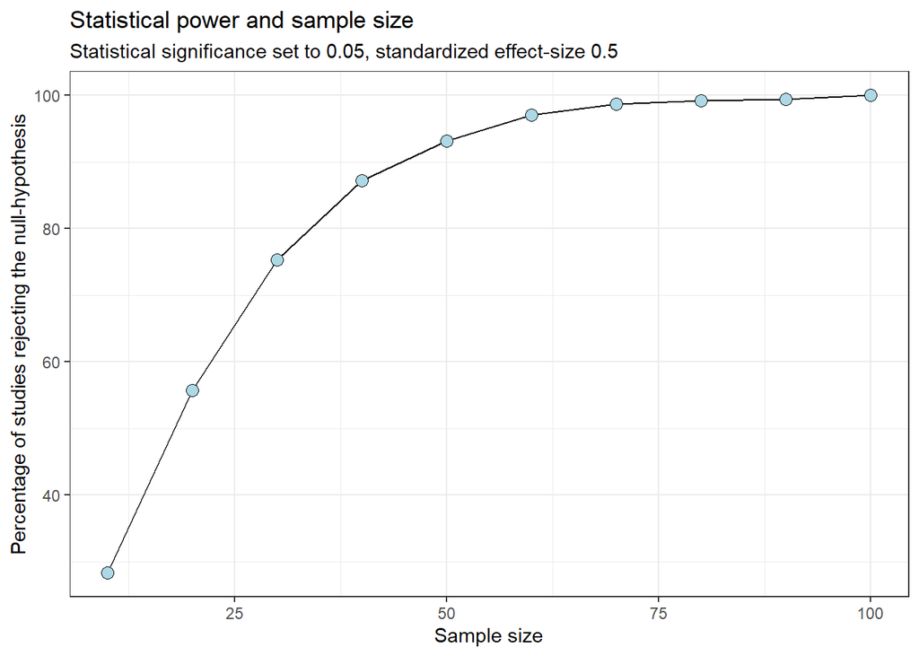

```r
# Count numbers of studies with p < 0.05
results_total %>%
  filter(pval < 0.05) %>%
  group_by(sample.size) %>%
  summarise(n = n(),
            prop = n / 1000) %>%
  ggplot(aes(sample.size, 100 * prop)) + geom_line() + geom_point(shape = 21, fill = "lightblue", size = 3) +
  labs(x = "Sample size",
       y = "Percentage of studies rejecting the null-hypothesis",
       title = "Statistical power and sample size",
       subtitle = "Statistical significance set to 0.05, standardized effect-size 0.5") +
  theme_bw()
```

- The relationship between power and sample size can be used to make cost-benefit analyses of future studies.
- The “cost” of a study can be regarded as e.g. economical or ethical.
- In most cases the power calculation can be done without simulations, using e.g. the `pwr` package.

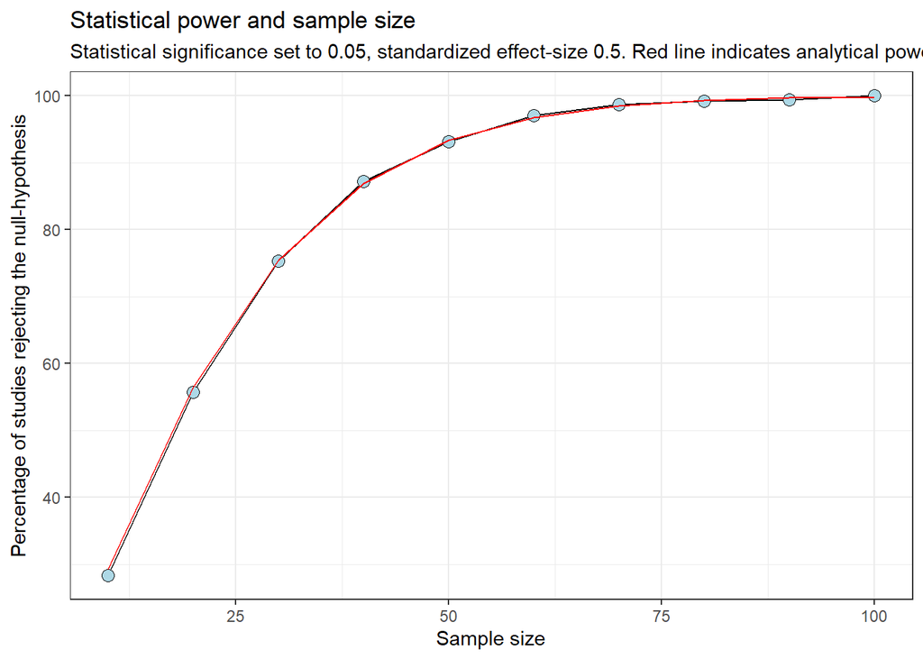

```r
library(pwr)

sample.sizes <- seq(from = 10, to = 100, by = 10)
results.pwr <- list()

for(i in 1:length(sample.sizes)) {

  pwr_analysis <- pwr.t.test(type = "one.sample", d = 5/10, sig.level = 0.05, n = sample.sizes[i])


  results.pwr[[i]] <- data.frame(sample.size = sample.sizes[i],
                                 prop = pwr_analysis$power)


  }

results.pwr <- bind_rows(results.pwr)

# Count numbers of studies with p < 0.05
results_total %>%
  filter(pval < 0.05) %>%
  group_by(sample.size) %>%
  summarise(n = n(),
            prop = n / 1000) %>%
  ggplot(aes(sample.size, 100 * prop)) +
  geom_line() +
  geom_point(shape = 21, fill = "lightblue", size = 3) +

  geom_line(data = results.pwr, color = "red") +

  labs(x = "Sample size",
       y = "Percentage of studies rejecting the null-hypothesis",
       title = "Statistical power and sample size",
       subtitle = "Statistical significance set to 0.05, standardized effect-size 0.5. Red line indicates analytical power.") +
  theme_bw()
```

### Effect size and statistical significance

- A standardized (observed) effect size may be calculated from each study. What is the relationship between effect-sizes, sample sizes and p-values?
- The p-value is directly related to the observed effect-size. The sample size determines the *p*-value at a specific effect-size.

[figure not shown]

```r
library(cowplot)


plotA <- results_total %>%
  ggplot(aes(effect.size, pval,
             color = as.factor(sample.size))) + geom_point() +
  labs(color = "Sample size") +

    geom_hline(yintercept = 0.05, color = "red") +
  annotate("text", x = 1.5, y = 0.05 + 0.1,
           color = "red",
           label = "P-value = 0.05",
           size = 2.5) +

  geom_hline(yintercept = 0.001, color = "blue") +
  annotate("text", x = 1.5, y = 0.001 + 0.1,
           color = "blue",
           label = "P-value = 0.01",
           size = 2.5) +

  labs(title = "Effect size vs. p-values",
       x = "Effect size",
       y = "P-value") +

  theme_bw() +
  theme(legend.position = "none")



plotB <- results_total %>%
  ggplot(aes(effect.size, -log(pval),
             color = as.factor(sample.size))) + geom_point() +
  labs(color = "Sample size",
       title = " ",
       x = "Effect size",
       y = "-log(p-value)") +

  geom_hline(yintercept = -log(0.05), color = "red") +
  annotate("text", x = -0.2, y = -log(0.05) + 1,
           color = "red",
           label = "P-value = 0.05",
           size = 2.5) +

  geom_hline(yintercept = -log(0.001), color = "blue") +
  annotate("text", x = -0.2, y = -log(0.001) + 1,
           color = "blue",
           label = "P-value = 0.01",
           size = 2.5) +
  scale_x_continuous(breaks = c(0, 0.5, 1, 2)) +


  theme_bw()

library(cowplot)
plot_grid(plotA, plotB, ncol = 2, rel_widths = c(0.8, 1))
```

- The observed effect size is an estimation of the population effect size. In our case, the population effect-size is $\frac{mean}{SD} = \frac{5}{10} = 0.5$.
- How well do we estimate effect sizes?

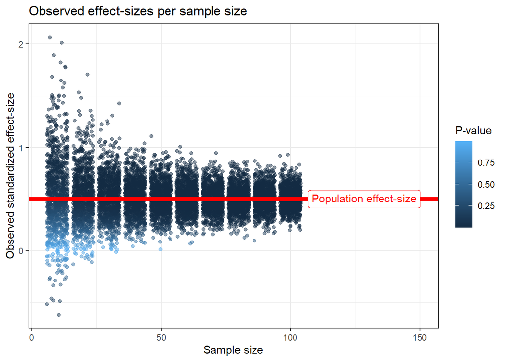

```r
library(ggtext)

results_total %>%
  ggplot(aes(sample.size, effect.size, color = pval)) +

  geom_point(position = position_jitter(), alpha = 0.5) +
    geom_hline(yintercept = pop.es, lty = 1, size = 2, color = "red") +
  labs(x = "Sample size",
       y = "Observed standardized effect-size",
       color = "P-value",
           title = "Observed effect-sizes per sample size") +
  annotate("richtext", x = 150, y = pop.es,
           color = "red",
           hjust = 1,
           label = "Population effect-size") +
  theme_bw()
```

### Effect of sample size on precision

- Precision could be regarded as the ability to estimate an effect with some degree of certainty.
- The confidence interval (CI) is constructed to find the true population effect at a given rate (e.g. 95% of studies).
- CI depends on the sample size:

$$95\%~CI:~Estimate \pm t_{\alpha/2, df = n-1} \times SE$$
$$95\%~CI:~Estimate \pm t_{\alpha/2, df = n-1} \times \frac{s}{\sqrt{n}}$$
For n = 10:

$$95\%~CI:~Estimate \pm 2.26 \times SE$$

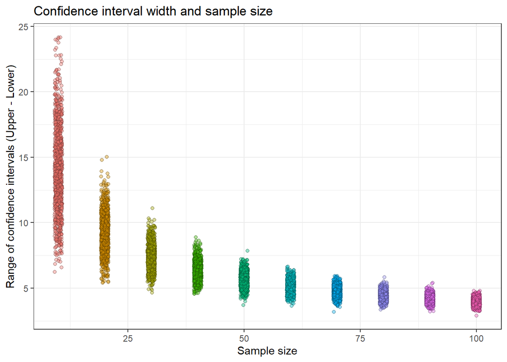

```r
results_total %>%
  ggplot(aes(sample.size, ci.upr-ci.lwr, fill = as.factor(sample.size))) +
  geom_point(position = position_jitter(width = 0.8),
             shape = 21, alpha = 0.4) +
  labs(x = "Sample size",
       y = "Range of confidence intervals (Upper - Lower)",
       title = "Confidence interval width and sample size") +
  theme_bw() +
  theme(legend.position = "none")
```

- To decrease the width of the confidence interval by half, we need to increase the sample size about 3-4 times.

```r
library(knitr)

results_total %>%
  mutate(ci_width = ci.upr-ci.lwr) %>%
  group_by(sample.size) %>%
  summarise(ci_width = mean(ci_width)) %>%
  kable(col.names = c("Sample size", "95% CI width"),
        digits = c(1, 1))
```

| Sample size | 95% CI width |
| --- | --- |
| 10 | 14.0 |
| 20 | 9.3 |
| 30 | 7.4 |
| 40 | 6.4 |
| 50 | 5.7 |
| 60 | 5.1 |
| 70 | 4.7 |
| 80 | 4.4 |
| 90 | 4.2 |
| 100 | 4.0 |

- The confidence interval covers the *true population parameter* in 95% of repeated studies. 1000 studies is not enough to reach exactly 95%.

```r
results_total %>%
  mutate(sig = if_else(ci.lwr <= 5 & ci.upr >= 5, "sig", "ns"),
         interval = paste0(rep(seq(1:1000), each = 10))) %>%
  filter(sig == "sig") %>%
  group_by(sample.size) %>%
  summarise(prop = 100 * (n() / 1000)) %>%
    kable(col.names = c("Sample size", "Proportion of 95% CI finding the true effect"),
        digits = c(1, 1))
```

| Sample size | Proportion of 95% CI finding the true effect |
| --- | --- |
| 10 | 95.1 |
| 20 | 95.1 |
| 30 | 95.1 |
| 40 | 95.1 |
| 50 | 95.2 |
| 60 | 94.1 |
| 70 | 94.5 |
| 80 | 94.8 |
| 90 | 94.0 |
| 100 | 94.6 |

- We will be wrong at the same rate with a given coverage of the confidence interval independent of the sample size.
- However, we could increase the *coverage* of the interval and maintain *precision* with a larger sample size

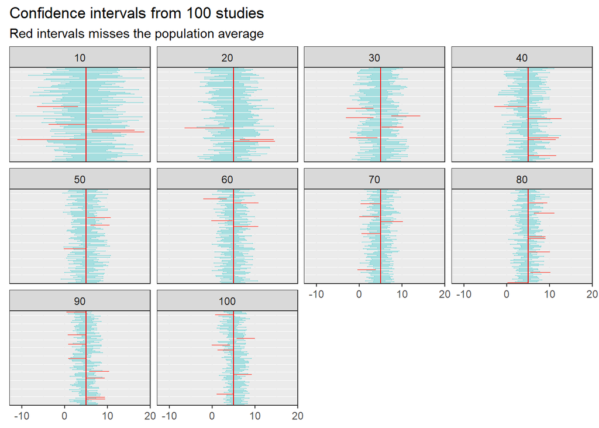

```r
results_total %>%
  mutate(sig = if_else(ci.lwr <= 5 & ci.upr >= 5, "sig", "ns"),
         interval = paste0(rep(seq(1:1000), each = 10))) %>%
  filter(interval %in% seq(1:100)) %>%

  ggplot(aes(mean, interval, color = sig, alpha = sig)) +
  geom_errorbarh(aes(xmin = ci.lwr,
                    xmax = ci.upr)) +

  scale_alpha_manual(values = c(1, 0.3)) +

  geom_vline(xintercept = 5, color = "red") +

  facet_wrap(~ sample.size) +

  labs(title = "Confidence intervals from 100 studies",
       subtitle = "Red intervals misses the population average") +
  theme_bw() +

  theme(axis.text.y = element_blank(),
        axis.ticks.y = element_blank(),
        legend.position = "none",
        axis.title = element_blank())
```

## What if there is no effect?

- Studies that examine a population effect that is close to zero will be wrong at rate of 5%, if the $\alpha$ level is set to 0.05.
- The “power” of such studies is 5% regardless of the sample size.

```r
library(tidyverse)
set.seed(1)


# Create a population to sample from with a known effect
# In standardized terms, the population effect is 0 = mean / sd.


population <- rnorm(10^6, 0, 10)

# Calculate the population effect size
pop.es <- mean(population) / sd(population)


results_total_null <- list()



# If use a progress bar
# pb <- txtProgressBar(min = 0, max = 1000, style = 3)


# 0. Inside for-loop:




for(i in 1:1000) {

# 1. Sample from the population with sample size 10 to 100

  # 1.1 create a vector of sample sizes
  sample.sizes <- seq(from = 10, to = 100, by = 10)
  # 1.2 create a list to store results
  results_sub <- list()

  # 1.3 Inside a nested for-loop, perform sampling with each sample size
  for(j in 1:length(sample.sizes)) {

  samp <- sample(population, sample.sizes[j],
                 replace = FALSE)


# 2. Create a model

  m <- lm(y ~ 1, data = data.frame(y = samp))

  # 2.1 Store results from each model as a data frame in a list:

 results_sub[[j]] <- data.frame(mean = coef(summary(m))[1, 1],  # Estimated mean
             se = coef(summary(m))[1, 2],  # Standard error
             pval = coef(summary(m))[1, 4],  # p-value
             ci.lwr = confint(m)[1], # confidence interval
             ci.upr = confint(m)[2], # confidence interval
             effect.size = mean(samp) / sd(samp),
             sample.size = sample.sizes[j]) # Sample size



  }
  # 2.2 Combine all data frames from each sample size as a data frame in a list

  results_total_null[[i]] <- bind_rows(results_sub)


  # 3. Repeat 1 and 2 1000 times, performing 1000 studies each with
  # sample sizes 10 to 100.

  # If we use a "progress bar"
  # setTxtProgressBar(pb, i)

}

# Close the progress bar
# close(pb)

# Combine all results
results_total_null <- bind_rows(results_total_null)
```

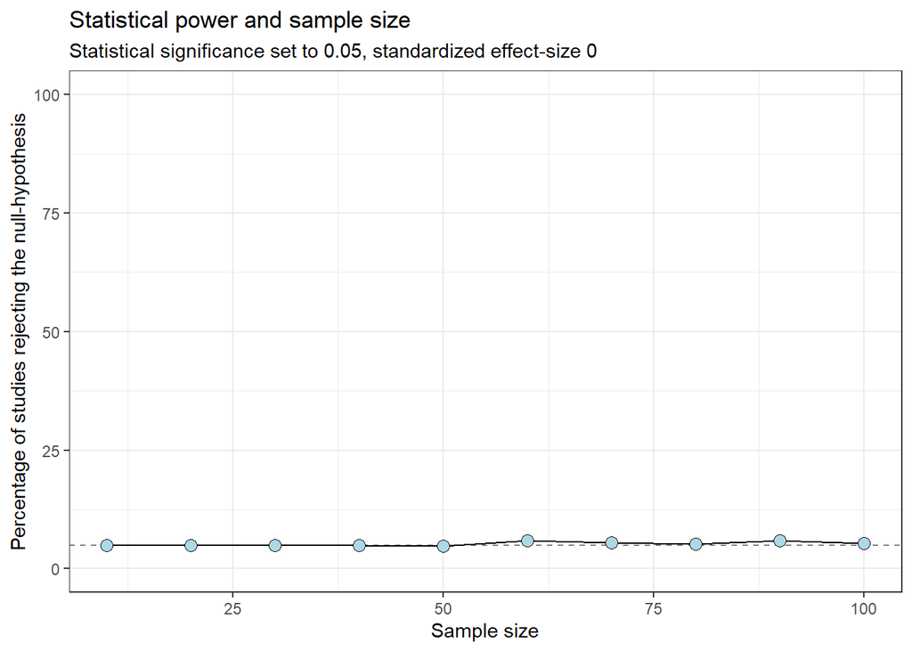

```r
# Count numbers of studies with p < 0.05
results_total_null %>%
  filter(pval < 0.05) %>%
  group_by(sample.size) %>%
  summarise(n = n(),
            prop = n / 1000) %>%
  ggplot(aes(sample.size, 100 * prop)) +
  geom_hline(yintercept = 5, lty = 2, color = "grey50") +
  geom_line() +
  geom_point(shape = 21, fill = "lightblue", size = 3) +
  labs(x = "Sample size",
       y = "Percentage of studies rejecting the null-hypothesis",
       title = "Statistical power and sample size",
       subtitle = "Statistical significance set to 0.05, standardized effect-size 0") +
  scale_y_continuous(limits = c(0, 100)) +
  theme_bw()
```

- P-values in studies examining population zero-effects will be uniformly distributed

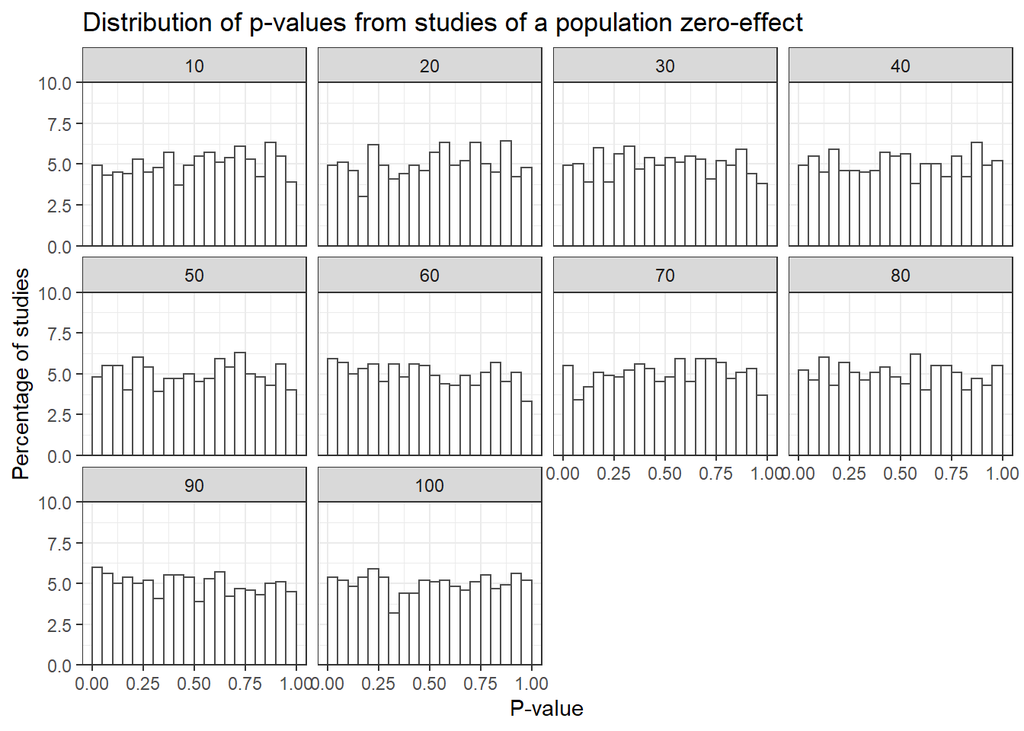

```r
results_total_null %>%
  ggplot(aes(pval)) +
  geom_histogram(aes(y=100 * ..count../1000),
                 binwidth = 0.05, boundary = 0, color = "gray30", fill = "white") +
  labs(x = "P-value",
       y = "Percentage of studies",
       title = "Distribution of p-values from studies of a population zero-effect") +
  scale_y_continuous(limits = c(0, 10), expand = c(0, 0)) +
  facet_wrap(~ sample.size) +
  theme_bw()
```

- Be aware of **p = 0.047**, this p-value can be more probable when sampling from the zero-effect population in certain cases, an example:

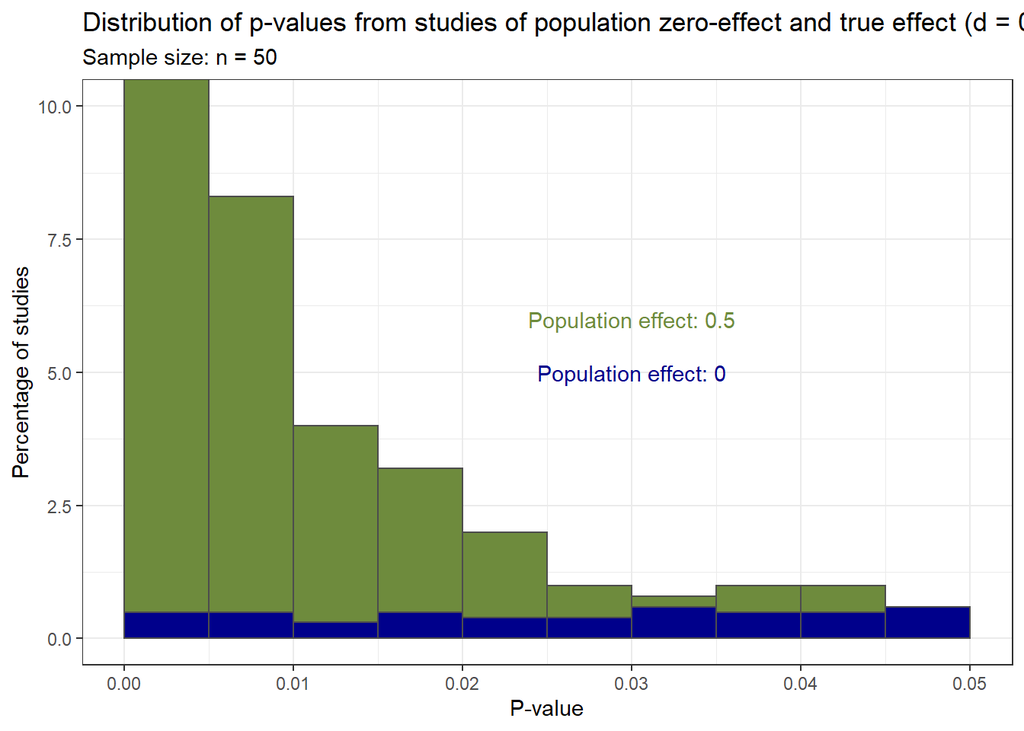

```r
results_total %>%
  filter(sample.size == 50,
         pval <= 0.05) %>%
    ggplot(aes(pval)) +
  geom_histogram(aes(y=100 * ..count../1000),
                 binwidth = 0.005, boundary = 0, color = "gray30", fill = "darkolivegreen4") +


    geom_histogram(data = results_total_null %>%
                          filter(sample.size == 50,
                                  pval <= 0.05),
  aes(y=100 * ..count../1000),
                 binwidth = 0.005, boundary = 0, color = "gray30", fill = "darkblue") +

    labs(x = "P-value",
       y = "Percentage of studies",
       title = "Distribution of p-values from studies of population zero-effect and true effect (d = 0.5)",
       subtitle = "Sample size: n = 50") +
  annotate("text", x = 0.03, y = 5, label = "Population effect: 0", color = "darkblue") +
  annotate("text", x = 0.03, y = 6, label = "Population effect: 0.5", color = "darkolivegreen4") +
  coord_cartesian(ylim=c(0,10)) +
  theme_bw()
```